# R ASSIGNMENT

aishanamugalu

2023-11-10

#SECTION A: Data Exploration 1 #Read the metaFile.csv file into your R sessions

```r
metadata <- read.csv("metaFile.csv")
View(metadata)
```

#iReturn the number of variables/columns and records/rows

```r
metadata
```

```
##    sample_id Participant Treatment
## 1   sample_1           C         4
## 2   sample_2           B         3
## 3   sample_3           B         2
## 4   sample_4           C         1
## 5   sample_5           C         3
## 6   sample_6           A         4
## 7   sample_7           B         0
## 8   sample_8           A         1
## 9   sample_9           B         4
## 10 sample_10           C         0
## 11 sample_11           A         2
## 12 sample_12           A         3
## 13 sample_13           B         1
## 14 sample_14           C         2
```

[output cut: 36 more lines]

```r
#number of columns
ncol(metadata)
```

```
## [1] 3
```

```r
#number of rows
nrow(metadata)
```

```
## [1] 50
```

```r
#retrieve dimensions of the data
dim(metadata)
```

```
## [1] 50  3
```

```r
#structure of the data
str(metadata)
```

```
## 'data.frame':    50 obs. of  3 variables:
##  $ sample_id  : chr  "sample_1" "sample_2" "sample_3" "sample_4" ...
##  $ Participant: chr  "C" "B" "B" "C" ...
##  $ Treatment  : int  4 3 2 1 3 4 0 1 4 0 ...
```

#ii. Count the number of samples which were obtained for each level of treatment

```r
#Loading libraries
library(dplyr)
```

```r
library(ggplot2)

table(metadata$Treatment)
```

```
##
##  0  1  2  3  4
##  9 10 10 11 10
```

```r
metadata %>% group_by(Treatment) %>% summarise(count = n())
```

```
## # A tibble: 5 × 2
##   Treatment count
##       <int> <int>
## 1         0     9
## 2         1    10
## 3         2    10
## 4         3    11
## 5         4    10
```

#iii. Count the number of samples which were obtained for each participant

```r
table(metadata$Participant)
```

```
##
##  A  B  C
## 15 17 18
```

```r
metadata %>%group_by(Participant) %>% summarise(count = n())
```

```
## # A tibble: 3 × 2
##   Participant count
##   <chr>       <int>
## 1 A              15
## 2 B              17
## 3 C              18
```

#iv. Extract records for samples obtained at treatment levels 0,2 and 4

```r
metadata[metadata$Treatment %in% c(0, 2, 4),]
```

```
##    sample_id Participant Treatment
## 1   sample_1           C         4
## 3   sample_3           B         2
## 6   sample_6           A         4
## 7   sample_7           B         0
## 9   sample_9           B         4
## 10 sample_10           C         0
## 11 sample_11           A         2
## 14 sample_14           C         2
## 15 sample_15           A         0
## 16 sample_16           C         4
## 18 sample_18           B         2
## 21 sample_21           A         4
## 22 sample_22           B         0
## 24 sample_24           B         4
## 25 sample_25           C         0
## 26 sample_26           A         2
## 29 sample_29           C         2
## 30 sample_30           A         0
## 31 sample_31           C         4
## 33 sample_33           B         2
## 36 sample_36           A         4
## 37 sample_37           B         0
## 39 sample_39           B         4
## 40 sample_40           C         0
## 41 sample_41           A         2
## 44 sample_44           C         2
## 45 sample_45           A         0
## 46 sample_46           C         4
## 48 sample_48           B         2
```

```r
metadata %>% filter(Treatment %in% c(0, 2, 4))
```

```
##    sample_id Participant Treatment
## 1   sample_1           C         4
## 2   sample_3           B         2
## 3   sample_6           A         4
## 4   sample_7           B         0
## 5   sample_9           B         4
## 6  sample_10           C         0
## 7  sample_11           A         2
## 8  sample_14           C         2
## 9  sample_15           A         0
## 10 sample_16           C         4
## 11 sample_18           B         2
## 12 sample_21           A         4
## 13 sample_22           B         0
## 14 sample_24           B         4
## 15 sample_25           C         0
## 16 sample_26           A         2
## 17 sample_29           C         2
## 18 sample_30           A         0
## 19 sample_31           C         4
## 20 sample_33           B         2
## 21 sample_36           A         4
## 22 sample_37           B         0
## 23 sample_39           B         4
## 24 sample_40           C         0
## 25 sample_41           A         2
## 26 sample_44           C         2
## 27 sample_45           A         0
## 28 sample_46           C         4
## 29 sample_48           B         2
```

```r
subset(metadata, Treatment %in% c(0, 2, 4))
```

```
##    sample_id Participant Treatment
## 1   sample_1           C         4
## 3   sample_3           B         2
## 6   sample_6           A         4
## 7   sample_7           B         0
## 9   sample_9           B         4
## 10 sample_10           C         0
## 11 sample_11           A         2
## 14 sample_14           C         2
## 15 sample_15           A         0
## 16 sample_16           C         4
## 18 sample_18           B         2
## 21 sample_21           A         4
## 22 sample_22           B         0
## 24 sample_24           B         4
## 25 sample_25           C         0
## 26 sample_26           A         2
## 29 sample_29           C         2
## 30 sample_30           A         0
## 31 sample_31           C         4
## 33 sample_33           B         2
## 36 sample_36           A         4
## 37 sample_37           B         0
## 39 sample_39           B         4
## 40 sample_40           C         0
## 41 sample_41           A         2
## 44 sample_44           C         2
## 45 sample_45           A         0
## 46 sample_46           C         4
## 48 sample_48           B         2
```

```r
filter(metadata, Treatment != 1 & Treatment != 3)
```

```
##    sample_id Participant Treatment
## 1   sample_1           C         4
## 2   sample_3           B         2
## 3   sample_6           A         4
## 4   sample_7           B         0
## 5   sample_9           B         4
## 6  sample_10           C         0
## 7  sample_11           A         2
## 8  sample_14           C         2
## 9  sample_15           A         0
## 10 sample_16           C         4
## 11 sample_18           B         2
## 12 sample_21           A         4
## 13 sample_22           B         0
## 14 sample_24           B         4
## 15 sample_25           C         0
## 16 sample_26           A         2
## 17 sample_29           C         2
## 18 sample_30           A         0
## 19 sample_31           C         4
## 20 sample_33           B         2
## 21 sample_36           A         4
## 22 sample_37           B         0
## 23 sample_39           B         4
## 24 sample_40           C         0
## 25 sample_41           A         2
## 26 sample_44           C         2
## 27 sample_45           A         0
## 28 sample_46           C         4
## 29 sample_48           B         2
```

```r
filter(metadata, Treatment == 0 | Treatment == 2 | Treatment == 4)
```

```
##    sample_id Participant Treatment
## 1   sample_1           C         4
## 2   sample_3           B         2
## 3   sample_6           A         4
## 4   sample_7           B         0
## 5   sample_9           B         4
## 6  sample_10           C         0
## 7  sample_11           A         2
## 8  sample_14           C         2
## 9  sample_15           A         0
## 10 sample_16           C         4
## 11 sample_18           B         2
## 12 sample_21           A         4
## 13 sample_22           B         0
## 14 sample_24           B         4
## 15 sample_25           C         0
## 16 sample_26           A         2
## 17 sample_29           C         2
## 18 sample_30           A         0
## 19 sample_31           C         4
## 20 sample_33           B         2
## 21 sample_36           A         4
## 22 sample_37           B         0
## 23 sample_39           B         4
## 24 sample_40           C         0
## 25 sample_41           A         2
## 26 sample_44           C         2
## 27 sample_45           A         0
## 28 sample_46           C         4
## 29 sample_48           B         2
```

#v. Extract records for samples obtained from participants A and C

```r
filter(metadata, Participant == "A" | Participant == "C")
```

```
##    sample_id Participant Treatment
## 1   sample_1           C         4
## 2   sample_4           C         1
## 3   sample_5           C         3
## 4   sample_6           A         4
## 5   sample_8           A         1
## 6  sample_10           C         0
## 7  sample_11           A         2
## 8  sample_12           A         3
## 9  sample_14           C         2
## 10 sample_15           A         0
## 11 sample_16           C         4
## 12 sample_19           C         1
## 13 sample_20           C         3
## 14 sample_21           A         4
```

[output cut: 19 more lines]

```r
subset(metadata, Participant %in% c("A", "C"))
```

```
##    sample_id Participant Treatment
## 1   sample_1           C         4
## 4   sample_4           C         1
## 5   sample_5           C         3
## 6   sample_6           A         4
## 8   sample_8           A         1
## 10 sample_10           C         0
## 11 sample_11           A         2
## 12 sample_12           A         3
## 14 sample_14           C         2
## 15 sample_15           A         0
## 16 sample_16           C         4
## 19 sample_19           C         1
## 20 sample_20           C         3
## 21 sample_21           A         4
```

[output cut: 19 more lines]

```r
filter(metadata, Participant != "B")
```

```
##    sample_id Participant Treatment
## 1   sample_1           C         4
## 2   sample_4           C         1
## 3   sample_5           C         3
## 4   sample_6           A         4
## 5   sample_8           A         1
## 6  sample_10           C         0
## 7  sample_11           A         2
## 8  sample_12           A         3
## 9  sample_14           C         2
## 10 sample_15           A         0
## 11 sample_16           C         4
## 12 sample_19           C         1
## 13 sample_20           C         3
## 14 sample_21           A         4
```

[output cut: 19 more lines]

```r
metadata %>% filter(Participant %in% c("A", "C"))
```

```
##    sample_id Participant Treatment
## 1   sample_1           C         4
## 2   sample_4           C         1
## 3   sample_5           C         3
## 4   sample_6           A         4
## 5   sample_8           A         1
## 6  sample_10           C         0
## 7  sample_11           A         2
## 8  sample_12           A         3
## 9  sample_14           C         2
## 10 sample_15           A         0
## 11 sample_16           C         4
## 12 sample_19           C         1
## 13 sample_20           C         3
## 14 sample_21           A         4
```

[output cut: 19 more lines]

#vi. Count the number of samples under each participant groups per treatment level

```r
table(metadata$Participant, metadata$Treatment)
```

```
##
##     0 1 2 3 4
##   A 3 3 3 3 3
##   B 3 3 4 4 3
##   C 3 4 3 4 4
```

#Section B: Data Exploration 2 #read the file into my R session

```r
Assignment <- read.csv("AssignmentFile.csv")
View(Assignment)
```

#iReturn the number of variables/columns and records/rows

```r
ncol(Assignment)
```

```
## [1] 4
```

```r
nrow(Assignment)
```

```
## [1] 50
```

```r
dim(Assignment)
```

```
## [1] 50  4
```

```r
str(Assignment)
```

```
## 'data.frame':    50 obs. of  4 variables:
##  $ samples: chr  "sample_1" "sample_2" "sample_3" "sample_4" ...
##  $ Conc1  : num  5.94 3.4 1.95 1.75 2.9 ...
##  $ Conc2  : num  2.29 4.05 1.29 4.51 2.6 ...
##  $ Conc3  : num  3.25 3.24 1.26 2.62 1.67 ...
```

#ii. Compute the average concentration for each of the concetrations (ie Conc1, Conc2 and Conc3)

```r
mean(Assignment$Conc1)
```

```
## [1] 2.23591
```

```r
mean(Assignment$Conc2)
```

```
## [1] 2.631801
```

```r
mean(Assignment$Conc3)
```

```
## [1] 2.57969
```

#iii. Compute the average Conc for each sample (Hint: Obtain this by taking the mean of Conc1, Conc2 and Conc3).

```r
rowMeans(Assignment [2:4])
```

```
##  [1] 3.824863 3.561779 1.499365 2.958203 2.390004 1.868026 2.409794 1.419867
##  [9] 3.306693 2.288922 2.056538 1.599757 2.451226 2.901506 3.258827 1.753767
## [17] 2.443834 2.657674 1.782624 2.034364 1.998999 2.163061 2.544692 2.452164
## [25] 2.092057 3.003388 3.313401 1.765348 1.624170 3.037058 2.448267 2.038269
## [33] 2.833067 1.957261 1.668823 2.192923 2.616311 3.646680 2.841996 2.949213
## [41] 3.229693 2.329251 3.211285 2.842079 2.998275 2.744949 1.683616 2.672564
## [49] 2.434259 2.322598
```

```r
#or
concmean <- rowMeans(Assignment[c("Conc1", "Conc2", "Conc3")])
```

#iv. Extend this data-frame by introducing a new variable say ”Concmean” to contain the average Concentration values computed above

```r
library(dplyr)
mutate(Assignment, concmean)
```

```
##      samples      Conc1     Conc2      Conc3 concmean
## 1   sample_1 5.93804869 2.2877765  3.2487625 3.824863
## 2   sample_2 3.39846291 4.0508845  3.2359883 3.561779
## 3   sample_3 1.94647521 1.2918230  1.2597982 1.499365
## 4   sample_4 1.75043775 4.5088147  2.6153558 2.958203
## 5   sample_5 2.90319389 2.6006057  1.6662130 2.390004
## 6   sample_6 0.74662991 3.5212946  1.3361532 1.868026
## 7   sample_7 2.61412606 1.7075223  2.9077324 2.409794
## 8   sample_8 2.86823250 0.6855859  0.7057831 1.419867
## 9   sample_9 4.25332693 1.5380970  4.1286548 3.306693
## 10 sample_10 2.53152856 1.4914619  2.8437762 2.288922
## 11 sample_11 2.02469134 1.0988479  3.0460737 2.056538
## 12 sample_12 1.68888486 1.5382037  1.5721820 1.599757
## 13 sample_13 0.07948294 1.8417749  5.4324201 2.451226
## 14 sample_14 2.35002162 2.8437762  3.5107200 2.901506
```

[output cut: 36 more lines]

```r
Assignment2 <- mutate(Assignment, concmean)
Assignment2
```

```
##      samples      Conc1     Conc2      Conc3 concmean
## 1   sample_1 5.93804869 2.2877765  3.2487625 3.824863
## 2   sample_2 3.39846291 4.0508845  3.2359883 3.561779
## 3   sample_3 1.94647521 1.2918230  1.2597982 1.499365
## 4   sample_4 1.75043775 4.5088147  2.6153558 2.958203
## 5   sample_5 2.90319389 2.6006057  1.6662130 2.390004
## 6   sample_6 0.74662991 3.5212946  1.3361532 1.868026
## 7   sample_7 2.61412606 1.7075223  2.9077324 2.409794
## 8   sample_8 2.86823250 0.6855859  0.7057831 1.419867
## 9   sample_9 4.25332693 1.5380970  4.1286548 3.306693
## 10 sample_10 2.53152856 1.4914619  2.8437762 2.288922
## 11 sample_11 2.02469134 1.0988479  3.0460737 2.056538
## 12 sample_12 1.68888486 1.5382037  1.5721820 1.599757
## 13 sample_13 0.07948294 1.8417749  5.4324201 2.451226
## 14 sample_14 2.35002162 2.8437762  3.5107200 2.901506
```

[output cut: 36 more lines]

#v. Obtain the basic statics (min, max, mean, median, quartiles, variance, standard deviation) for all the variables including Concmean

```r
sapply(Assignment2[,2:5], min)
```

```
##       Conc1       Conc2       Conc3    concmean
##  0.07948294  0.68558588 -0.27549366  1.41986718
```

```r
sapply(Assignment2[,2:5], max)
```

```
##    Conc1    Conc2    Conc3 concmean
## 5.938049 4.770579 5.432420 3.824863
```

```r
sapply(Assignment2[,2:5], mean)
```

```
##    Conc1    Conc2    Conc3 concmean
## 2.235910 2.631801 2.579690 2.482467
```

```r
sapply(Assignment2[,2:5], sd)
```

```
##     Conc1     Conc2     Conc3  concmean
## 1.0384617 0.9653108 1.1169179 0.6018165
```

```r
sapply(Assignment2[,2:5], var)
```

```
##     Conc1     Conc2     Conc3  concmean
## 1.0784026 0.9318250 1.2475056 0.3621831
```

```r
sapply(Assignment2[,2:5], median)
```

```
##    Conc1    Conc2    Conc3 concmean
## 2.222266 2.596348 2.642415 2.446051
```

```r
sapply(Assignment2[,2:5], quantile)
```

```
##           Conc1     Conc2      Conc3 concmean
## 0%   0.07948294 0.6855859 -0.2754937 1.419867
## 25%  1.64835372 1.8380425  1.8432362 2.035340
## 50%  2.22226569 2.5963481  2.6424150 2.446051
## 75%  2.72488059 3.2873422  3.1898175 2.937286
## 100% 5.93804869 4.7705793  5.4324201 3.824863
```

#SECTION C: Data Manipulation and Graphics

#i. Remove variables Conc1, Conc2 and Conc3 from the concentration data-frame (At this point, this data-frame should only have information about sample ids and average Conc.)

```r
library(dplyr)
new_assignment2 <- select (Assignment2,  "samples", "concmean")

new_assignment2
```

```
##      samples concmean
## 1   sample_1 3.824863
## 2   sample_2 3.561779
## 3   sample_3 1.499365
## 4   sample_4 2.958203
## 5   sample_5 2.390004
## 6   sample_6 1.868026
## 7   sample_7 2.409794
## 8   sample_8 1.419867
## 9   sample_9 3.306693
## 10 sample_10 2.288922
## 11 sample_11 2.056538
## 12 sample_12 1.599757
## 13 sample_13 2.451226
## 14 sample_14 2.901506
```

[output cut: 36 more lines]

#ii. Combine (merge) information in the two data-frames concentration with metadata.

```r
merge_data <- merge(metadata, new_assignment2, by.x = "sample_id",
                    by.y = "samples", all = T)
merge_data
```

```
##    sample_id Participant Treatment concmean
## 1   sample_1           C         4 3.824863
## 2  sample_10           C         0 2.288922
## 3  sample_11           A         2 2.056538
## 4  sample_12           A         3 1.599757
## 5  sample_13           B         1 2.451226
## 6  sample_14           C         2 2.901506
## 7  sample_15           A         0 3.258827
## 8  sample_16           C         4 1.753767
## 9  sample_17           B         3 2.443834
## 10 sample_18           B         2 2.657674
## 11 sample_19           C         1 1.782624
## 12  sample_2           B         3 3.561779
## 13 sample_20           C         3 2.034364
## 14 sample_21           A         4 1.998999
```

[output cut: 36 more lines]

#iii. Check the size of the combined data-frame and verify it is what is expected (Hint: You may want to use the dim() and colnames() and head() functions).

```r
dim(merge_data)
```

```
## [1] 50  4
```

```r
colnames(merge_data)
```

```
## [1] "sample_id"   "Participant" "Treatment"   "concmean"
```

```r
#verify the dataframe
head(merge_data)
```

```
##   sample_id Participant Treatment concmean
## 1  sample_1           C         4 3.824863
## 2 sample_10           C         0 2.288922
## 3 sample_11           A         2 2.056538
## 4 sample_12           A         3 1.599757
## 5 sample_13           B         1 2.451226
## 6 sample_14           C         2 2.901506
```

#iv. From the combined dataset, extract records for samples for participants B and C obtained at treatment levels 2,3 and 4. Assign this to variable “participantsBC”.

```r
participantsBC <- merge_data[merge_data$Participant %in% c("B","C") &
                          merge_data$Treatment %in% c("2","3","4"),]
participantsBC
```

```
##    sample_id Participant Treatment concmean
## 1   sample_1           C         4 3.824863
## 6  sample_14           C         2 2.901506
## 8  sample_16           C         4 1.753767
## 9  sample_17           B         3 2.443834
## 10 sample_18           B         2 2.657674
## 12  sample_2           B         3 3.561779
## 13 sample_20           C         3 2.034364
## 17 sample_24           B         4 2.452164
## 22 sample_29           C         2 1.624170
## 23  sample_3           B         2 1.499365
## 25 sample_31           C         4 2.448267
## 26 sample_32           B         3 2.038269
## 27 sample_33           B         2 2.833067
## 29 sample_35           C         3 1.668823
## 33 sample_39           B         4 2.841996
## 39 sample_44           C         2 2.842079
## 41 sample_46           C         4 2.744949
## 42 sample_47           B         3 1.683616
## 43 sample_48           B         2 2.672564
## 45  sample_5           C         3 2.390004
## 46 sample_50           C         3 2.322598
## 50  sample_9           B         4 3.306693
```

#v. Using ”participantsBC” or otherwise, compute the average Concentration for participants B and C under treatments 2, 3 and 4. (Hint: Aggregate or group_by function). In this case, we expect to get a single Concentration value for each participant for each treatment.

```r
participantsBCmean2 <- participantsBC %>%
   group_by(Participant, Treatment) %>%
  summarise(avg_conc = mean(concmean))
participantsBCmean2
```

```
## # A tibble: 6 × 3
## # Groups:   Participant [2]
##   Participant Treatment avg_conc
##   <chr>           <int>    <dbl>
## 1 B                   2     2.42
## 2 B                   3     2.43
## 3 B                   4     2.87
## 4 C                   2     2.46
## 5 C                   3     2.10
## 6 C                   4     2.69
```

#vi. Use a for loop to change treatment levels from 0,1,2,3,4 to “very-low”, “low”, “moderate”, “high”, “very-high” respectively on the combined dataset.

```r
merge_data_loop <- merge_data
merge_data_loop
```

```
##    sample_id Participant Treatment concmean
## 1   sample_1           C         4 3.824863
## 2  sample_10           C         0 2.288922
## 3  sample_11           A         2 2.056538
## 4  sample_12           A         3 1.599757
## 5  sample_13           B         1 2.451226
## 6  sample_14           C         2 2.901506
## 7  sample_15           A         0 3.258827
## 8  sample_16           C         4 1.753767
## 9  sample_17           B         3 2.443834
## 10 sample_18           B         2 2.657674
## 11 sample_19           C         1 1.782624
## 12  sample_2           B         3 3.561779
## 13 sample_20           C         3 2.034364
## 14 sample_21           A         4 1.998999
```

[output cut: 36 more lines]

```r
for (r in 1:nrow(merge_data_loop)){
  if (merge_data_loop[r,3]==0){
    merge_data_loop[r,3]= "Very low"
  } else if (merge_data_loop[r,3]==1){
    merge_data_loop[r,3]="Low"
  } else if (merge_data_loop[r,3]==2){
    merge_data_loop[r,3]="Moderate"
  } else {
    merge_data_loop[r,3]="Very High"
  }
}

  merge_data_loop
```

```
##    sample_id Participant Treatment concmean
## 1   sample_1           C Very High 3.824863
## 2  sample_10           C  Very low 2.288922
## 3  sample_11           A  Moderate 2.056538
## 4  sample_12           A Very High 1.599757
## 5  sample_13           B       Low 2.451226
## 6  sample_14           C  Moderate 2.901506
## 7  sample_15           A  Very low 3.258827
## 8  sample_16           C Very High 1.753767
## 9  sample_17           B Very High 2.443834
## 10 sample_18           B  Moderate 2.657674
## 11 sample_19           C       Low 1.782624
## 12  sample_2           B Very High 3.561779
## 13 sample_20           C Very High 2.034364
## 14 sample_21           A Very High 1.998999
```

[output cut: 36 more lines]

#vii. Write a function to change treatment levels from 0,1,2,3,4 to ”very-low”, ”low”, ”moderate”, ”high”, ”very-high” respectively, use this with sapply() or other appropriate function to change treatment variable in combined dataset

```r
merge_data_func <- merge_data
merge_data_func
```

```
##    sample_id Participant Treatment concmean
## 1   sample_1           C         4 3.824863
## 2  sample_10           C         0 2.288922
## 3  sample_11           A         2 2.056538
## 4  sample_12           A         3 1.599757
## 5  sample_13           B         1 2.451226
## 6  sample_14           C         2 2.901506
## 7  sample_15           A         0 3.258827
## 8  sample_16           C         4 1.753767
## 9  sample_17           B         3 2.443834
## 10 sample_18           B         2 2.657674
## 11 sample_19           C         1 1.782624
## 12  sample_2           B         3 3.561779
## 13 sample_20           C         3 2.034364
## 14 sample_21           A         4 1.998999
```

[output cut: 36 more lines]

```r
labels_function <- function(x) {
  labels <- ifelse(x==0, "very low",
                   ifelse(x==1, "low",
                   ifelse(x==2, "moderate",
                          ifelse(x==3, "high",
                                 ifelse(x==4, "very high", NA)))))
  return(labels)
}

merge_data_func$Treatment <- sapply(merge_data_func$Treatment, labels_function)
merge_data_func
```

```
##    sample_id Participant Treatment concmean
## 1   sample_1           C very high 3.824863
## 2  sample_10           C  very low 2.288922
## 3  sample_11           A  moderate 2.056538
## 4  sample_12           A      high 1.599757
## 5  sample_13           B       low 2.451226
## 6  sample_14           C  moderate 2.901506
## 7  sample_15           A  very low 3.258827
## 8  sample_16           C very high 1.753767
## 9  sample_17           B      high 2.443834
## 10 sample_18           B  moderate 2.657674
## 11 sample_19           C       low 1.782624
## 12  sample_2           B      high 3.561779
## 13 sample_20           C      high 2.034364
## 14 sample_21           A very high 1.998999
```

[output cut: 36 more lines]

#viii. Check and comment on the time taken to perform the above two operations using the for loop and sapply(). (Hint: Use system.time() function).

```r
system.time( for (r in 1:nrow(merge_data)){
  if (merge_data[r,3]==0){
    merge_data[r,3]= "Very low"
  } else if (merge_data[r,3]==1){
    merge_data[r,3]="Low"
  } else if (merge_data[r,3]==2){
    merge_data[r,3]="Moderate"
  } else {
    merge_data[r,3]="Very High"
  }
}
)
```

```
##    user  system elapsed
##    0.02    0.00    0.01
```

```r
system.time(merge_data$Treatment <- sapply(merge_data$Treatment, labels_function))
```

```
##    user  system elapsed
##       0       0       0
```

#ix. Using ggplot2 package, produce appropriate graphical representation of the combined dataset with the changed treatment levels. You may produce more than one form of plot. Export the image(s) as PNG, the plots should at-least have the following; – Legend – Title – Axis labels – White background

[figure not shown]

```r
library(ggplot2)
ggplot(merge_data, aes(x=Treatment, y=concmean, fill=Participant)) +
 geom_boxplot() +
         theme_bw() +
         facet_wrap(~Participant)
```

#SECTION D : Classical hypothesis testing and statistical models in R. #i first read my data into R.

```r
statsFile <- read.csv("~/R class/classwork-galiwango/fwdmsb7102bioconductorandrprogrammingassignment/statsFile.csv")
View(statsFile)
```

#PART_1 : How does BMI relate to BP for the all study participants?

#assess whether our data follows a parametric distribution using a histogram #to determine the relationship between BMI & BP,we use the correlation “cor()” function. #this will give me a correlation coefficient between the two variables which maybe pearson,kendall or spearman. #correlation is measured by a correlation coefficient which ranges between -1 to +1. #correlation coefficient quantifies the strength and direction of the linear relationship. A correlation close to 1 indicates a strong positive relationship, close to -1 indicates a strong negative relationship, and close to 0 indicates a weak or no linear relationship. #since our data has two quatitative parametric variables, i use pearsons method. #i will visualize the correlation using a scatterplot

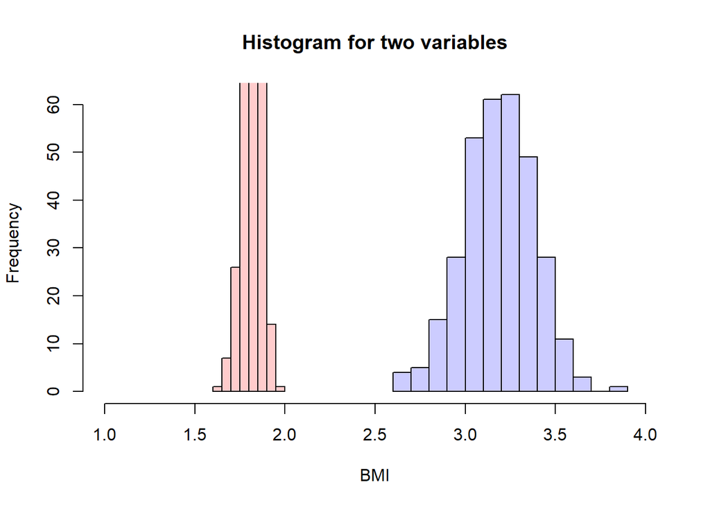

```r
#null hypthoses is that there is no relationship between BMI and BP for all study participants
#A histogram to visualize the distribution of values for our two variables variable.
hist(statsFile$BMI, col=rgb(0,0,1,0.2), xlim=c(1, 4),
     xlab='BMI', ylab='Frequency', main='Histogram for two variables')
hist(statsFile$BP, col=rgb(1,0,0,0.2), add=TRUE)
```

```r
#our data follows a parametric distribution ie mean and median are equal
#we proceed to use pearsons method

?cor.test
```

```
## starting httpd help server ... done
```

```r
correlation <- cor(statsFile$BMI, statsFile$BP)
print(correlation)
```

```
## [1] 0.9997509
```

```r
#the correlation is 0.99 which is close to 1 thus indicating a strong positive relationship
correlation_test <- cor.test(statsFile$BMI, statsFile$BP)
correlation_test <- cor.test(statsFile$BMI, statsFile$BP, method = "pearson")
print(correlation_test)
```

```
##
##  Pearson's product-moment correlation
##
## data:  statsFile$BMI and statsFile$BP
## t = 798.75, df = 318, p-value < 2.2e-16
## alternative hypothesis: true correlation is not equal to 0
## 95 percent confidence interval:
##  0.9996895 0.9998001
## sample estimates:
##       cor
## 0.9997509
```